# DBBM Final Project

shaistamadad

5/15/2020

## Read in the dataset

```r
library(readr)
PimaIndiansDiabetes <- read_csv("PimaIndiansDiabetes.csv")
head(PimaIndiansDiabetes)
```

```
## # A tibble: 6 x 9
##   Pregnancies Glucose BloodPressure SkinThickness Insulin   BMI DiabetesPedigre~
##         <dbl>   <dbl>         <dbl>         <dbl>   <dbl> <dbl>            <dbl>
## 1           6     148            72            35       0  33.6            0.627
## 2           1      85            66            29       0  26.6            0.351
## 3           8     183            64             0       0  23.3            0.672
## 4           1      89            66            23      94  28.1            0.167
## 5           0     137            40            35     168  43.1            2.29
## 6           5     116            74             0       0  25.6            0.201
## # ... with 2 more variables: Age <dbl>, Outcome <dbl>
```

```r
str(PimaIndiansDiabetes)
```

```
## Classes 'spec_tbl_df', 'tbl_df', 'tbl' and 'data.frame': 768 obs. of  9 variables:
##  $ Pregnancies             : num  6 1 8 1 0 5 3 10 2 8 ...
##  $ Glucose                 : num  148 85 183 89 137 116 78 115 197 125 ...
##  $ BloodPressure           : num  72 66 64 66 40 74 50 0 70 96 ...
##  $ SkinThickness           : num  35 29 0 23 35 0 32 0 45 0 ...
##  $ Insulin                 : num  0 0 0 94 168 0 88 0 543 0 ...
##  $ BMI                     : num  33.6 26.6 23.3 28.1 43.1 25.6 31 35.3 30.5 0 ...
##  $ DiabetesPedigreeFunction: num  0.627 0.351 0.672 0.167 2.288 ...
##  $ Age                     : num  50 31 32 21 33 30 26 29 53 54 ...
##  $ Outcome                 : num  1 0 1 0 1 0 1 0 1 1 ...
##  - attr(*, "spec")=
##   .. cols(
##   ..   Pregnancies = col_double(),
##   ..   Glucose = col_double(),
##   ..   BloodPressure = col_double(),
##   ..   SkinThickness = col_double(),
##   ..   Insulin = col_double(),
##   ..   BMI = col_double(),
##   ..   DiabetesPedigreeFunction = col_double(),
##   ..   Age = col_double(),
##   ..   Outcome = col_double()
##   .. )
```

#Q1: Which variables are numeric and which are categorical? Explain why. (20pts) ##Make sure to convert the variables to the correct type.

Let’s start with the definition of a numeric and categorical variables. Numeric variables are variables whose value can either be counted or measured. A numeric variable can be either continuous (where the value is measured) or discrete, where the value is being counted. A continuous numeric variable, in theory, could take any value in an interval, however this is limited by the precision of the measuring instrument. A discrete quantitative variable can take specific numeric values (rather than any value in an interval), but those numeric values have a clear quantitative interpretation. Examples of discrete quantitative variables is the number of pregnancies (i.e., it is not possible to have 1.5 pregnancies).

In contrast, categorical variables take on values in one of K different classes, or categories. Each observation can be placed in only one category, and the categories are mutually exclusive. Examples of catergorical class variables include a person’s gender (male or female); stages of cancer (benign, maligant)

Pregnancies: The number of pregancies can be counted and it takes a discrete set of values (0,1 2), there can’t be 1.2 pregnancies. Hence this is a discrete numeric variable.

Glucose: Plasma glucose concentration a 2 hours in an oral glucose tolerance test : continuous numeric variable which can take any value in an interval.

BloodPressure: Diastolic blood pressure (mm Hg): continous numeric variable which is measured and can take on any value in an interval but is limited by the measuring instrument sphygmomanometer’s accuracy.

SkinThickness: Triceps skin fold thickness (mm) : continous numeric as it is measured

Insulin: 2-Hour serum insulin (mu U/ml) : continous numeric as it is measured

BMI: Body mass index (weight in kg/(height in m)^2): continouse numeric as it is measured

DiabetesPedigreeFunction: Diabetes pedigree function : numeric as it is calculated based on a patient’s family history of diabetes. Diabetes Pedigree Function is function that represents how likely they are to get the disease by extrapolating from their ancestor’s history. The values in the DPF column shows a range of values, hence this is a continous numeric variable

Age: Age (years): numeric. There can be some debate about whether to classify age as discrete or continous numeric. If the decimals in age are use to represent the months and days of year, age can potentially be a continous numeric variable, however,since there are no decimal points in age here, I will take age as a dicrete numeric variable.

Outcome: Class variable (0 or 1)" : categorical variable as the outcome is classified into one of two categories: 0 representing not diabetic, and 1 presenting diabetic. I will further classify this as a nominal categorical variable as outcome belongs one of two categories.

##Convert outcome from numeric to categorical, the rest of the variables are correctly classified as numeric

```r
PimaIndiansDiabetes$Outcome= as.factor(PimaIndiansDiabetes$Outcome)
#PimaIndiansDiabetes$Pregnancies= as.factor(PimaIndiansDiabetes$Pregnancies)
```

```r
str(PimaIndiansDiabetes)
```

```
## Classes 'spec_tbl_df', 'tbl_df', 'tbl' and 'data.frame': 768 obs. of  9 variables:
##  $ Pregnancies             : num  6 1 8 1 0 5 3 10 2 8 ...
##  $ Glucose                 : num  148 85 183 89 137 116 78 115 197 125 ...
##  $ BloodPressure           : num  72 66 64 66 40 74 50 0 70 96 ...
##  $ SkinThickness           : num  35 29 0 23 35 0 32 0 45 0 ...
##  $ Insulin                 : num  0 0 0 94 168 0 88 0 543 0 ...
##  $ BMI                     : num  33.6 26.6 23.3 28.1 43.1 25.6 31 35.3 30.5 0 ...
##  $ DiabetesPedigreeFunction: num  0.627 0.351 0.672 0.167 2.288 ...
##  $ Age                     : num  50 31 32 21 33 30 26 29 53 54 ...
##  $ Outcome                 : Factor w/ 2 levels "0","1": 2 1 2 1 2 1 2 1 2 2 ...
##  - attr(*, "spec")=
##   .. cols(
##   ..   Pregnancies = col_double(),
##   ..   Glucose = col_double(),
##   ..   BloodPressure = col_double(),
##   ..   SkinThickness = col_double(),
##   ..   Insulin = col_double(),
##   ..   BMI = col_double(),
##   ..   DiabetesPedigreeFunction = col_double(),
##   ..   Age = col_double(),
##   ..   Outcome = col_double()
##   .. )
```

```r
head(PimaIndiansDiabetes)
```

```
## # A tibble: 6 x 9
##   Pregnancies Glucose BloodPressure SkinThickness Insulin   BMI DiabetesPedigre~
##         <dbl>   <dbl>         <dbl>         <dbl>   <dbl> <dbl>            <dbl>
## 1           6     148            72            35       0  33.6            0.627
## 2           1      85            66            29       0  26.6            0.351
## 3           8     183            64             0       0  23.3            0.672
## 4           1      89            66            23      94  28.1            0.167
## 5           0     137            40            35     168  43.1            2.29
## 6           5     116            74             0       0  25.6            0.201
## # ... with 2 more variables: Age <dbl>, Outcome <fct>
```

##There are 500 rows which have no diabetes outcome in the data, and 268 rows which have diabetes outcome in the data

```r
table(PimaIndiansDiabetes$Outcome)
```

```
##
##   0   1
## 500 268
```

#Q2: Use appropriate statistical analysis to determine which of the variables ( on their own ) are most helpful in predicting the outcome? (20pts) ##For each variable draw an appropriate graph ( boxplot for numerical values and barplot for categorical values). Explain your answer.

## I will use three different statistical analysis methods to check which of the 8 variables are most helpful in predicting the outcome on their own:

1. Information Gain
2. Boxplots (as all variables are numeric, no barplots are needed)
3. correlation matrix with pearson correlation score between each variable and the outcome to see which variable has the highest correlation score. Using these three different methods, I will create a rank from top to bottom for the variables. The ones at the top are most helpful in predicting the outcome on their own, and the ones at the bottom are the least helpful.

##1) Information Gain Information gain calculates the reduction in entropy or surprise from transforming a dataset in some way.Information gain is generally used to create decision trees. This is because a decision tree starts with a variable which has the highest information gain. For each node of the tree, the information value measures how much information a feature gives us about the outcome. The split with the highest information gain will be taken as the first split and the process will continue until all children nodes are pure, or until the information gain is 0.Information gain can also be used for feature selection, by evaluating the gain of each variable in the context of the target variable (which is the outcome in this case).

```r
library(CORElearn) # need this package to calculate the information gain
Information_Gain1= attrEval(Outcome~.,
              data=PimaIndiansDiabetes, estimator = "InfGain")
Information_Gain1
```

```
##              Pregnancies                  Glucose            BloodPressure
##               0.03918026               0.13081032               0.01404912
##            SkinThickness                  Insulin                      BMI
##               0.01690311               0.02680195               0.07489856
## DiabetesPedigreeFunction                      Age
##               0.02079640               0.07247271
```

```r
IG_FD=data.frame(Information_Gain1)
IG_FD$Information_Gain1= as.numeric(IG_FD$Information_Gain1)
rownames(IG_FD)
```

```
## [1] "Pregnancies"              "Glucose"
## [3] "BloodPressure"            "SkinThickness"
## [5] "Insulin"                  "BMI"
## [7] "DiabetesPedigreeFunction" "Age"
```

Let’s plot a bar plot to visualise this information

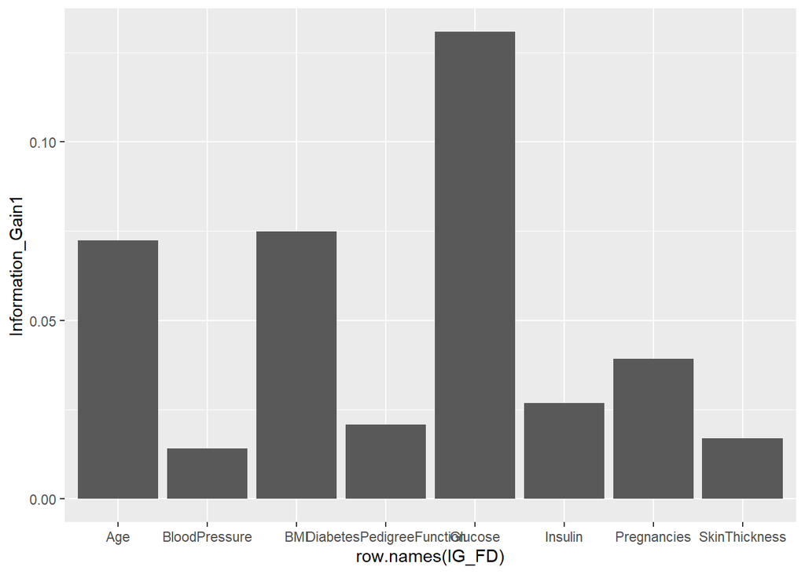

```r
library(ggplot2)
# Basic barplot
p<-ggplot(data=IG_FD, aes(x=row.names(IG_FD), y=Information_Gain1)) +
  geom_bar(stat="identity")
p
```

## Conclusion from Information Gain

Best Variable is Glucose; worse is blood pressure, glucose has highest information gain, and blood pressure has the lowest

```r
IG_FD
```

```
##                          Information_Gain1
## Pregnancies                     0.03918026
## Glucose                         0.13081032
## BloodPressure                   0.01404912
## SkinThickness                   0.01690311
## Insulin                         0.02680195
## BMI                             0.07489856
## DiabetesPedigreeFunction        0.02079640
## Age                             0.07247271
```

## Box plots

```r
library(gridExtra) # for arranging boxplots in a row to make visualisation and comparison easier
library(ggplot2)
Pregnancy= ggplot(PimaIndiansDiabetes, aes(x=Outcome, y=Pregnancies)) +
  geom_boxplot(notch=TRUE,outlier.colour="red", outlier.shape=1,
                outlier.size=3)
```

```r
Glucose=ggplot(PimaIndiansDiabetes, aes(x=Outcome, y=Glucose)) +
  geom_boxplot(notch=TRUE,outlier.colour="red", outlier.shape=1,
                outlier.size=3)
```

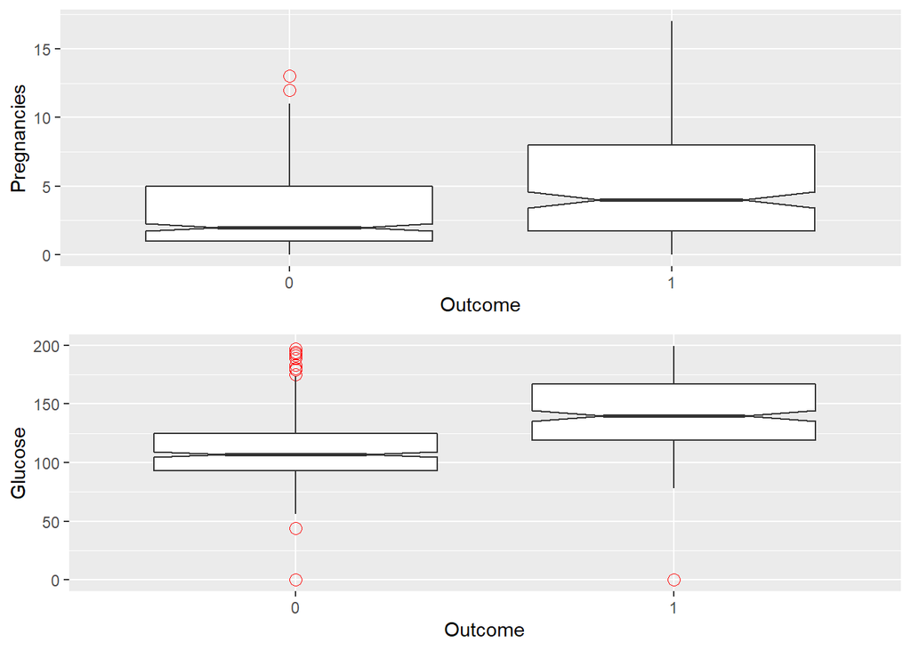

```r
grid.arrange(Pregnancy, Glucose, nrow = 2)
```

The means for diabetes and no diabetes prediction are separated in pregnancy, higher median pregancies in diabetes positive outcome, although, the upper quartile of no diabetes overlaps a lot with the lower and upper quartiles of diabetes positive boxplot.

Glucose shows a very clear separation of median scores between the 1 and 0 predicitioons. Higher levels in prediction=1. Also note the very little overlap between th lower quartile of prediction=1 and upper quartile of prediction = 0

```r
BloodPressure=ggplot(PimaIndiansDiabetes, aes(x=Outcome, y=BloodPressure)) +
  geom_boxplot(notch=TRUE,outlier.colour="red", outlier.shape=1,
                outlier.size=3)
```

```r
SkinThickness=ggplot(PimaIndiansDiabetes, aes(x=Outcome, y=SkinThickness)) +
  geom_boxplot(notch=TRUE,outlier.colour="red", outlier.shape=1,
                outlier.size=3)
```

```r
Insulin=ggplot(PimaIndiansDiabetes, aes(x=Outcome, y=Insulin)) +
  geom_boxplot(notch=FALSE,outlier.colour="red", outlier.shape=1,
                outlier.size=3)
```

```r
BMI=ggplot(PimaIndiansDiabetes, aes(x=Outcome, y=BMI)) +
  geom_boxplot(notch=TRUE,outlier.colour="red", outlier.shape=1,
                outlier.size=3)
```

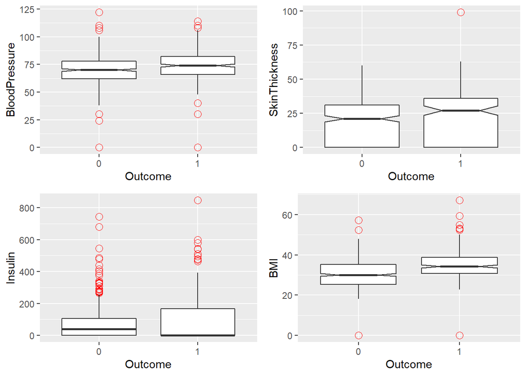

```r
grid.arrange(BloodPressure,SkinThickness,Insulin,BMI, nrow = 2)
```

Blood pressure: medians for the two outcomes are very near each other, with a lot of overlap between the upper and lower quantiles and lots of outliers. Hence, BP is not a good predictor on its own. The medians and upper and lower quantiles for skin thickness are also very close for the two outcomes. So, skin thickness is also not a good variable in terms of prediction powerr. Insulin is also not a good predicor, eve though the median for prediction= 1 is lower, the upper quantile of the prediction=1 is very wide and overlaps with the upper and lower quantiles of prediction=0, also note that high number of outliers. The mdain of BMI is higher for prediction=1, BMI is a decent predictor, compared to the other variables.

```r
DPF=ggplot(PimaIndiansDiabetes, aes(x=Outcome, y=DiabetesPedigreeFunction)) +
  geom_boxplot(notch=TRUE,outlier.colour="red", outlier.shape=1,
                outlier.size=3)
```

```r
Age=ggplot(PimaIndiansDiabetes, aes(x=Outcome, y=Age)) +
  geom_boxplot(notch=TRUE,outlier.colour="red", outlier.shape=1,
                outlier.size=3)
```

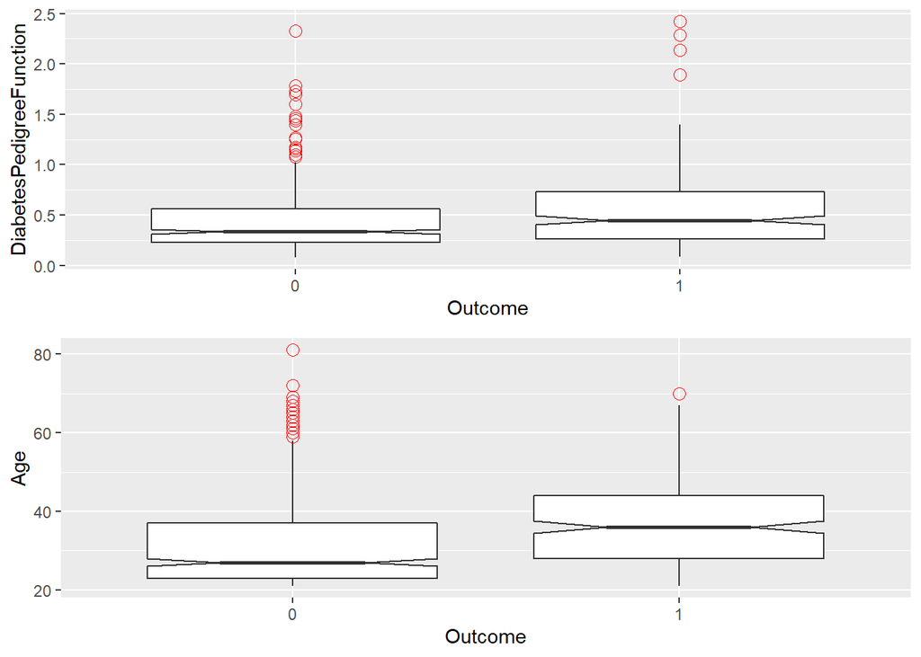

```r
grid.arrange(DPF,Age, nrow = 2)
```

The median for prediction=1 is higher in the DPF boxplor, although the interquartile ranges do overlap. Age shows a clear separation of median: higher median when prediction=1.

# Conclusion based on boxplots

Glucose is most accurate in predicting by itself because it has the least overlap between the inter-quantile range in the diabetes(1) and no diabetes (0) conditions, which gives the highest confidence fot this variable out of the eight that the medians differ between the two conditions (diabetes and no diabetes). Glucose also has the one of the least number of outliers. Pregnancies,BMI, Age are also good predictors. DPF is moderate. Insulin, skin thickness, and blood pressure are not good in predicting the outcome on their own.

## Analysis Method 3: Correlation Heatmap

Note: Reference: Code taken and adapted from the following source: http://www.sthda.com/english/wiki/ggplot2-quick-correlation-matrix-heatmap-r-software-and-data-visualization

```r
Correlation.data= PimaIndiansDiabetes
Correlation.data$Outcome= as.numeric(Correlation.data$Outcome)
cormat <- round(cor(Correlation.data),2)
head(cormat)
```

```
##               Pregnancies Glucose BloodPressure SkinThickness Insulin  BMI
## Pregnancies          1.00    0.13          0.14         -0.08   -0.07 0.02
## Glucose              0.13    1.00          0.15          0.06    0.33 0.22
## BloodPressure        0.14    0.15          1.00          0.21    0.09 0.28
## SkinThickness       -0.08    0.06          0.21          1.00    0.44 0.39
## Insulin             -0.07    0.33          0.09          0.44    1.00 0.20
## BMI                  0.02    0.22          0.28          0.39    0.20 1.00
##               DiabetesPedigreeFunction   Age Outcome
## Pregnancies                      -0.03  0.54    0.22
## Glucose                           0.14  0.26    0.47
## BloodPressure                     0.04  0.24    0.07
## SkinThickness                     0.18 -0.11    0.07
## Insulin                           0.19 -0.04    0.13
## BMI                               0.14  0.04    0.29
```

```r
library(reshape2)
melted_cormat <- melt(cormat)
head(melted_cormat)
```

```
##            Var1        Var2 value
## 1   Pregnancies Pregnancies  1.00
## 2       Glucose Pregnancies  0.13
## 3 BloodPressure Pregnancies  0.14
## 4 SkinThickness Pregnancies -0.08
## 5       Insulin Pregnancies -0.07
## 6           BMI Pregnancies  0.02
```

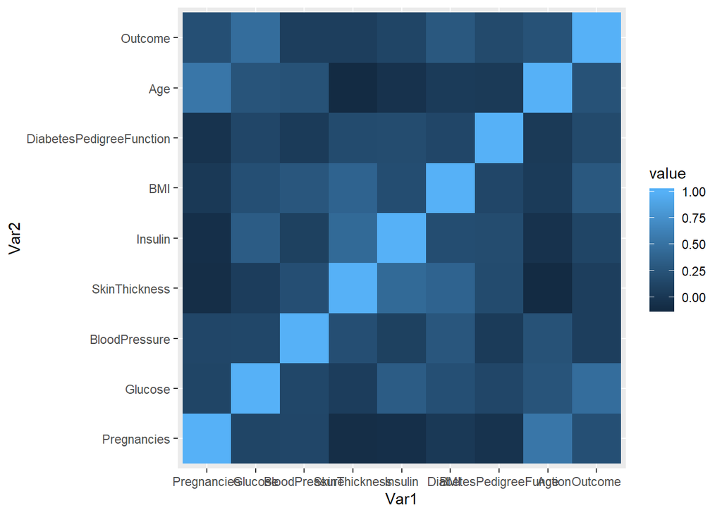

```r
library(ggplot2)
ggplot(data = melted_cormat, aes(x=Var1, y=Var2, fill=value)) +
  geom_tile()
```

```r
# Get lower triangle of the correlation matrix
  get_lower_tri<-function(cormat){
    cormat[upper.tri(cormat)] <- NA
    return(cormat)
  }
  # Get upper triangle of the correlation matrix
  get_upper_tri <- function(cormat){
    cormat[lower.tri(cormat)]<- NA
    return(cormat)
  }
```

```r
upper_tri <- get_upper_tri(cormat)
upper_tri
```

```
##                          Pregnancies Glucose BloodPressure SkinThickness
## Pregnancies                        1    0.13          0.14         -0.08
## Glucose                           NA    1.00          0.15          0.06
## BloodPressure                     NA      NA          1.00          0.21
## SkinThickness                     NA      NA            NA          1.00
## Insulin                           NA      NA            NA            NA
## BMI                               NA      NA            NA            NA
## DiabetesPedigreeFunction          NA      NA            NA            NA
## Age                               NA      NA            NA            NA
## Outcome                           NA      NA            NA            NA
##                          Insulin  BMI DiabetesPedigreeFunction   Age Outcome
## Pregnancies                -0.07 0.02                    -0.03  0.54    0.22
## Glucose                     0.33 0.22                     0.14  0.26    0.47
## BloodPressure               0.09 0.28                     0.04  0.24    0.07
## SkinThickness               0.44 0.39                     0.18 -0.11    0.07
## Insulin                     1.00 0.20                     0.19 -0.04    0.13
## BMI                           NA 1.00                     0.14  0.04    0.29
## DiabetesPedigreeFunction      NA   NA                     1.00  0.03    0.17
## Age                           NA   NA                       NA  1.00    0.24
## Outcome                       NA   NA                       NA    NA    1.00
```

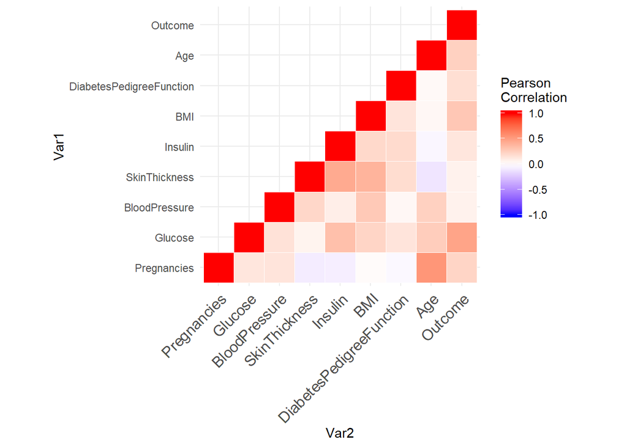

```r
# Melt the correlation matrix
library(reshape2)
melted_cormat <- melt(upper_tri, na.rm = TRUE)
# Heatmap
library(ggplot2)
ggplot(data = melted_cormat, aes(Var2, Var1, fill = value))+
 geom_tile(color = "white")+
 scale_fill_gradient2(low = "blue", high = "red", mid = "white",
   midpoint = 0, limit = c(-1,1), space = "Lab",
   name="Pearson\nCorrelation") +
  theme_minimal()+
 theme(axis.text.x = element_text(angle = 45, vjust = 1,
    size = 12, hjust = 1))+
 coord_fixed()
```

```r
reorder_cormat <- function(cormat){
# Use correlation between variables as distance
dd <- as.dist((1-cormat)/2)
hc <- hclust(dd)
cormat <-cormat[hc$order, hc$order]
}
```

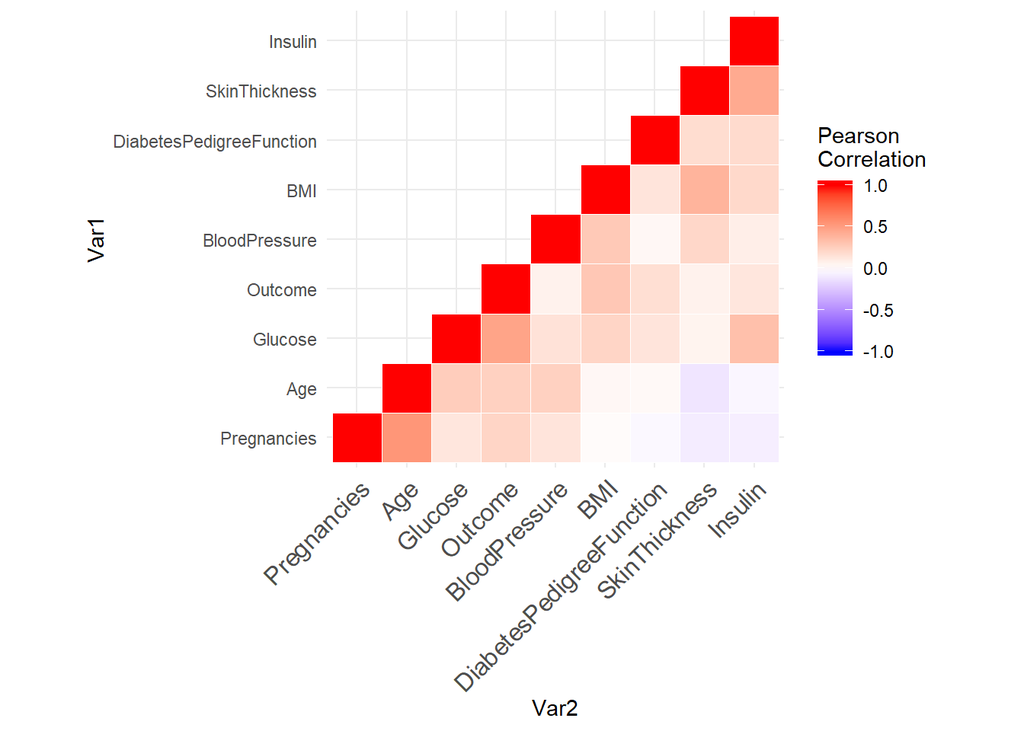

```r
# Reorder the correlation matrix
cormat <- reorder_cormat(cormat)
upper_tri <- get_upper_tri(cormat)
# Melt the correlation matrix
melted_cormat <- melt(upper_tri, na.rm = TRUE)
# Create a ggheatmap
ggheatmap <- ggplot(melted_cormat, aes(Var2, Var1, fill = value))+
 geom_tile(color = "white")+
 scale_fill_gradient2(low = "blue", high = "red", mid = "white",
   midpoint = 0, limit = c(-1,1), space = "Lab",
    name="Pearson\nCorrelation") +
  theme_minimal()+ # minimal theme
 theme(axis.text.x = element_text(angle = 45, vjust = 1,
    size = 12, hjust = 1))+
 coord_fixed()
# Print the heatmap
print(ggheatmap)
```

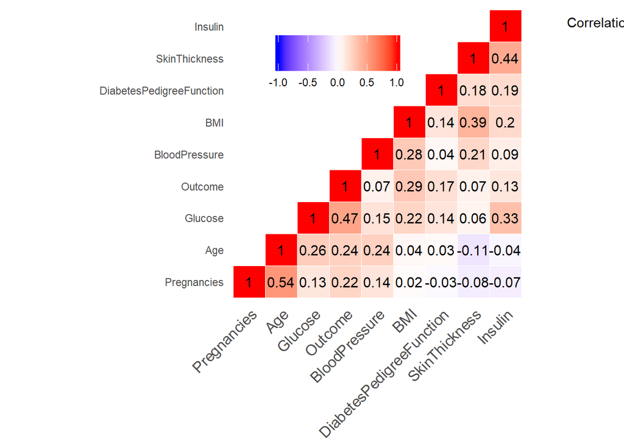

```r
ggheatmap +
geom_text(aes(Var2, Var1, label = value), color = "black", size = 4) +
theme(
  axis.title.x = element_blank(),
  axis.title.y = element_blank(),
  panel.grid.major = element_blank(),
  panel.border = element_blank(),
  panel.background = element_blank(),
  axis.ticks = element_blank(),
  legend.justification = c(1, 0),
  legend.position = c(0.6, 0.7),
  legend.direction = "horizontal")+
  guides(fill = guide_colorbar(barwidth = 7, barheight = 2,
                title.position = "top", title.hjust = 5))
```

## Analysis of the pearson correlation co-efficients between outcome and the variables: (and ranking of variables from best to worst explanatory prediction power)

Outcome and Glucose=0.47 Outcome and BMI= 0.290 Outcome and Age=0.240 Outcome and Pregnancy: 0.22 Outcome and DPF= 0.17 Outcome and Insulin= 0.13 Outcome and Skin Thickness= 0.07 Outcome and BP= 0.07

#Q3: Are there any missing values? and how do we fix this ? (20pts) ##Notice that some of the values are missing and replaced with 0. For example a blood pressure of 0 doesn’t make sense and it can have an impact on the models. So how do we identify which 0 reoresents the value 0 and which represents NA? Explain your answer.

```r
pima <- PimaIndiansDiabetes[complete.cases(PimaIndiansDiabetes),]
dim(pima)
```

```
## [1] 768   9
```

There seem to be no NAs in any of the rows, as the dimensions remain the same after filtering the data for complete cases only. However,there were 0’s for BloodPressure, SkinThickness, Insulin, BMI, Glucose and Pregancies, and outcome. The 0s for outcome and pregancies make sense. 0 in outcome represents no diabetes, whereas 0 in pregnancies alos makes sense as a woman can be diabetic while having no pregnancy history. 0 for the rest do not make sense. BMI can’t be zero, neither can skin thickness, insulin levels can’t be zero (don’t represent the physiological range)

I have fixed the NAs using methods 1 and 2. I used the imputed dataframe for choosing my model, as getting rid of all NAs reduced the dataset quite drastically.

```r
PimaIndiansDiabetes1= PimaIndiansDiabetes[,c(2:8)]  #variables which need to be imputed
head(PimaIndiansDiabetes1)
```

```
## # A tibble: 6 x 7
##   Glucose BloodPressure SkinThickness Insulin   BMI DiabetesPedigreeFunct~   Age
##     <dbl>         <dbl>         <dbl>   <dbl> <dbl>                  <dbl> <dbl>
## 1     148            72            35       0  33.6                  0.627    50
## 2      85            66            29       0  26.6                  0.351    31
## 3     183            64             0       0  23.3                  0.672    32
## 4      89            66            23      94  28.1                  0.167    21
## 5     137            40            35     168  43.1                  2.29     33
## 6     116            74             0       0  25.6                  0.201    30
```

```r
PimaIndiansDiabetes1[PimaIndiansDiabetes1 == 0] <- NA  # change all 0s to NAs .
head(PimaIndiansDiabetes1)
```

```
## # A tibble: 6 x 7
##   Glucose BloodPressure SkinThickness Insulin   BMI DiabetesPedigreeFunct~   Age
##     <dbl>         <dbl>         <dbl>   <dbl> <dbl>                  <dbl> <dbl>
## 1     148            72            35      NA  33.6                  0.627    50
## 2      85            66            29      NA  26.6                  0.351    31
## 3     183            64            NA      NA  23.3                  0.672    32
## 4      89            66            23      94  28.1                  0.167    21
## 5     137            40            35     168  43.1                  2.29     33
## 6     116            74            NA      NA  25.6                  0.201    30
```

## Check if code actually worke and 0s are replaced with NA

```r
# Return the column names containing missing observations
list_na <- colnames(PimaIndiansDiabetes1)[ apply(PimaIndiansDiabetes1, 2, anyNA) ]
list_na
```

```
## [1] "Glucose"       "BloodPressure" "SkinThickness" "Insulin"
## [5] "BMI"
```

## Summary of total number of missing data for each variable

```r
summary(PimaIndiansDiabetes1$Glucose)
```

```
##    Min. 1st Qu.  Median    Mean 3rd Qu.    Max.    NA's
##    44.0    99.0   117.0   121.7   141.0   199.0       5
```

```r
summary(PimaIndiansDiabetes1$BloodPressure)
```

```
##    Min. 1st Qu.  Median    Mean 3rd Qu.    Max.    NA's
##   24.00   64.00   72.00   72.41   80.00  122.00      35
```

```r
summary(PimaIndiansDiabetes1$SkinThickness)
```

```
##    Min. 1st Qu.  Median    Mean 3rd Qu.    Max.    NA's
##    7.00   22.00   29.00   29.15   36.00   99.00     227
```

```r
summary(PimaIndiansDiabetes1$Insulin)
```

```
##    Min. 1st Qu.  Median    Mean 3rd Qu.    Max.    NA's
##   14.00   76.25  125.00  155.55  190.00  846.00     374
```

```r
summary(PimaIndiansDiabetes1$BMI)
```

```
##    Min. 1st Qu.  Median    Mean 3rd Qu.    Max.    NA's
##   18.20   27.50   32.30   32.46   36.60   67.10      11
```

```r
summary(PimaIndiansDiabetes1$DiabetesPedigreeFunction) # no missing values
```

```
##    Min. 1st Qu.  Median    Mean 3rd Qu.    Max.
##  0.0780  0.2437  0.3725  0.4719  0.6262  2.4200
```

```r
summary(PimaIndiansDiabetes1$Age) # no missing values
```

```
##    Min. 1st Qu.  Median    Mean 3rd Qu.    Max.
##   21.00   24.00   29.00   33.24   41.00   81.00
```

# Method 1: getting rid of NA value rows

```r
Data_Clean1= cbind(PimaIndiansDiabetes$Pregnancies,PimaIndiansDiabetes1,PimaIndiansDiabetes$Outcome)
Data_Clean1_Final= na.omit(Data_Clean1)
dim(Data_Clean1_Final)
```

```
## [1] 392   9
```

## after omitting all the rows with NAs,only 392 left.

## Can also use dplyr to omit the rows

```r
library(dplyr)
# Exclude the missing observations
PimaIndiansDiabetes1_drop <-Data_Clean1 %>%
na.omit()
colnames(PimaIndiansDiabetes1_drop)= colnames(PimaIndiansDiabetes)
dim(PimaIndiansDiabetes1_drop)
```

```
## [1] 392   9
```

#Final Data with all NA values omitted

```r
str(PimaIndiansDiabetes1_drop)
```

```
## 'data.frame':    392 obs. of  9 variables:
##  $ Pregnancies             : num  1 0 3 2 1 5 0 1 1 3 ...
##  $ Glucose                 : num  89 137 78 197 189 166 118 103 115 126 ...
##  $ BloodPressure           : num  66 40 50 70 60 72 84 30 70 88 ...
##  $ SkinThickness           : num  23 35 32 45 23 19 47 38 30 41 ...
##  $ Insulin                 : num  94 168 88 543 846 175 230 83 96 235 ...
##  $ BMI                     : num  28.1 43.1 31 30.5 30.1 25.8 45.8 43.3 34.6 39.3 ...
##  $ DiabetesPedigreeFunction: num  0.167 2.288 0.248 0.158 0.398 ...
##  $ Age                     : num  21 33 26 53 59 51 31 33 32 27 ...
##  $ Outcome                 : Factor w/ 2 levels "0","1": 1 2 2 2 2 2 2 1 2 1 ...
##  - attr(*, "na.action")= 'omit' Named int  1 2 3 6 8 10 11 12 13 16 ...
##   ..- attr(*, "names")= chr  "1" "2" "3" "6" ...
```

# Method 2: Impute Values

```r
PimaIndiansDiabetes1_Means<- colMeans(PimaIndiansDiabetes1[,1:7], na.rm=TRUE) # calculate means for imputing
PimaIndiansDiabetes1_Means
```

```
##                  Glucose            BloodPressure            SkinThickness
##              121.6867628               72.4051842               29.1534196
##                  Insulin                      BMI DiabetesPedigreeFunction
##              155.5482234               32.4574637                0.4718763
##                      Age
##               33.2408854
```

```r
average_missing <- apply(PimaIndiansDiabetes1[,colnames(PimaIndiansDiabetes1) %in% list_na],
      2,
      mean,
      na.rm =  TRUE)
average_missing
```

```
##       Glucose BloodPressure SkinThickness       Insulin           BMI
##     121.68676      72.40518      29.15342     155.54822      32.45746
```

```r
sum(is.na(PimaIndiansDiabetes1$Glucose))
```

```
## [1] 5
```

```r
sum(is.na(PimaIndiansDiabetes1$BloodPressure))
```

```
## [1] 35
```

```r
sum(is.na(PimaIndiansDiabetes1$SkinThickness))
```

```
## [1] 227
```

```r
sum(is.na(PimaIndiansDiabetes1$Insulin))
```

```
## [1] 374
```

```r
sum(is.na(PimaIndiansDiabetes1$BMI))
```

```
## [1] 11
```

```r
colnames(PimaIndiansDiabetes1)
```

```
## [1] "Glucose"                  "BloodPressure"
## [3] "SkinThickness"            "Insulin"
## [5] "BMI"                      "DiabetesPedigreeFunction"
## [7] "Age"
```

```r
PimaIndiansDiabetes1_replace <- PimaIndiansDiabetes1 %>%
   mutate(replace_mean_glucose  = ifelse(is.na(Glucose), average_missing[1], Glucose),
   replace_mean_bloodpressure = ifelse(is.na(BloodPressure), average_missing[2], BloodPressure),
   replace_mean_skinthickness = ifelse(is.na(SkinThickness), average_missing[3], SkinThickness),
   replace_mean_Insulin = ifelse(is.na(Insulin), average_missing[4], Insulin),
   replace_mean_bmi= ifelse(is.na(BMI), average_missing[5], BMI)
   )
```

```r
PimaIndiansDiabetes_Imputed= cbind(PimaIndiansDiabetes$Pregnancies, PimaIndiansDiabetes1_replace[,c(8:12)], PimaIndiansDiabetes[,c(7:9)])
```

```r
colnames(PimaIndiansDiabetes_Imputed)= colnames(PimaIndiansDiabetes)
head(PimaIndiansDiabetes_Imputed)
```

```
##   Pregnancies Glucose BloodPressure SkinThickness  Insulin  BMI
## 1           6     148            72      35.00000 155.5482 33.6
## 2           1      85            66      29.00000 155.5482 26.6
## 3           8     183            64      29.15342 155.5482 23.3
## 4           1      89            66      23.00000  94.0000 28.1
## 5           0     137            40      35.00000 168.0000 43.1
## 6           5     116            74      29.15342 155.5482 25.6
##   DiabetesPedigreeFunction Age Outcome
## 1                    0.627  50       1
## 2                    0.351  31       0
## 3                    0.672  32       1
## 4                    0.167  21       0
## 5                    2.288  33       1
## 6                    0.201  30       0
```

## I realsied later a more efficient way to impute would have been to use the impute function from Hmisc package, but I had used the method above so decided to use the imputed data using the method above.

library(Hmisc) impute(PimaIndiansDiabetes1$BloodPressure, mean) # replace with mean impute(PimaIndiansDiabetes1$BloodPressure, median)

Do this for all five columns with the missing values.

# Method 2 for imputing

```r
PimaIndiansDiabetes1_impute_mean <- data.frame(
    sapply(
        PimaIndiansDiabetes1,
        function(x) ifelse(is.na(x),
            mean(x, na.rm = TRUE),
            x)))  # apply mean for all values if it is an NA, otherwise skip
```

```r
PimaIndiansDiabetes1_impute_mean2= cbind(PimaIndiansDiabetes$Pregnancies, PimaIndiansDiabetes1_impute_mean, PimaIndiansDiabetes$Outcome)  # get the final imputed dataframe by binding the pregnancies and outcome columns which did not need to be impyed
```

```r
colnames(PimaIndiansDiabetes1_impute_mean2)= colnames(PimaIndiansDiabetes)
head(PimaIndiansDiabetes1_impute_mean2)
```

```
##   Pregnancies Glucose BloodPressure SkinThickness  Insulin  BMI
## 1           6     148            72      35.00000 155.5482 33.6
## 2           1      85            66      29.00000 155.5482 26.6
## 3           8     183            64      29.15342 155.5482 23.3
## 4           1      89            66      23.00000  94.0000 28.1
## 5           0     137            40      35.00000 168.0000 43.1
## 6           5     116            74      29.15342 155.5482 25.6
##   DiabetesPedigreeFunction Age Outcome
## 1                    0.627  50       1
## 2                    0.351  31       0
## 3                    0.672  32       1
## 4                    0.167  21       0
## 5                    2.288  33       1
## 6                    0.201  30       0
```

Need to get rid of the extra decimal places

```r
PimaIndiansDiabetes1_impute_mean2$Glucose= round(PimaIndiansDiabetes1_impute_mean2$Glucose)
PimaIndiansDiabetes1_impute_mean2$BloodPressure= round(PimaIndiansDiabetes1_impute_mean2$BloodPressure)
PimaIndiansDiabetes1_impute_mean2$SkinThickness=round (PimaIndiansDiabetes1_impute_mean2$SkinThickness)
PimaIndiansDiabetes1_impute_mean2$Insulin= round(PimaIndiansDiabetes1_impute_mean2$Insulin)
PimaIndiansDiabetes1_impute_mean2$BMI= round(PimaIndiansDiabetes1_impute_mean2$BMI,digits = 1)
head(PimaIndiansDiabetes1_impute_mean2)
```

```
##   Pregnancies Glucose BloodPressure SkinThickness Insulin  BMI
## 1           6     148            72            35     156 33.6
## 2           1      85            66            29     156 26.6
## 3           8     183            64            29     156 23.3
## 4           1      89            66            23      94 28.1
## 5           0     137            40            35     168 43.1
## 6           5     116            74            29     156 25.6
##   DiabetesPedigreeFunction Age Outcome
## 1                    0.627  50       1
## 2                    0.351  31       0
## 3                    0.672  32       1
## 4                    0.167  21       0
## 5                    2.288  33       1
## 6                    0.201  30       0
```

#Final Imputed Data which I used in subsequenct analysis is PimaIndiansDiabetes1_impute_mean2

```r
str(PimaIndiansDiabetes1_impute_mean2)
```

```
## 'data.frame':    768 obs. of  9 variables:
##  $ Pregnancies             : num  6 1 8 1 0 5 3 10 2 8 ...
##  $ Glucose                 : num  148 85 183 89 137 116 78 115 197 125 ...
##  $ BloodPressure           : num  72 66 64 66 40 74 50 72 70 96 ...
##  $ SkinThickness           : num  35 29 29 23 35 29 32 29 45 29 ...
##  $ Insulin                 : num  156 156 156 94 168 156 88 156 543 156 ...
##  $ BMI                     : num  33.6 26.6 23.3 28.1 43.1 25.6 31 35.3 30.5 32.5 ...
##  $ DiabetesPedigreeFunction: num  0.627 0.351 0.672 0.167 2.288 ...
##  $ Age                     : num  50 31 32 21 33 30 26 29 53 54 ...
##  $ Outcome                 : Factor w/ 2 levels "0","1": 2 1 2 1 2 1 2 1 2 2 ...
```

#Q4: Building the Model (20pts) · You are free to use either : leave out 30% or 10xfold Cross Validation for your testing purpose. ##· You may pick any of the following to perform your modeling ( randomForest, SVM, KNN, or neural nets) · Explain your approach ( for example, if you are only picking one, why did you pick it? if you are going to do all, how will you decide which is best?)

I used the 30% leave out method. I also balanced my dataframe. This is because the number of 0 diagnosis = 500, and diabetic diagnosis is 268. This means there is a bias towards a no diabetes prediction by sheer number of the number of no diabetes rows.

## Balancing the Dataset

```r
table(PimaIndiansDiabetes1_impute_mean2[,"Outcome"])
```

```
##
##   0   1
## 500 268
```

```r
set.seed(1) # before sampling so that I get this result when I knit the file
allZeros<-PimaIndiansDiabetes1_impute_mean2[which(PimaIndiansDiabetes1_impute_mean2[,"Outcome"] == '0'),] # choose all the data with not diabetic diagnosis
allOnes<-PimaIndiansDiabetes1_impute_mean2[which(PimaIndiansDiabetes1_impute_mean2[,"Outcome"] == '1'),]   # choose all the data with diabetec diagnosis
set.seed(109)
sample(1:nrow(allZeros), nrow(allOnes))->rand.0  # sample from the allZeros vector number of variables = 268, which is the number of not diabetic data points
allZeros[rand.0,]->zero # 268 not diabetic data points
```

```r
set.seed(2)
training.ones<-sample(nrow(allOnes), floor(nrow(allOnes) * 0.7), replace = FALSE) #choose 70 percent of the 268 diabetic points
set.seed(3)
training.zeros= sample(nrow(zero), floor(nrow(zero) * 0.7), replace = FALSE) #choose 70 percent of the not diabetic points

training_set_balanced_ones<-allOnes[training.ones,] # 70 percent diabetic points for training set

test_set_balanced_ones<-allOnes[-training.ones,] # 30 percent chosen as test dataset

training_set_balanced_zeros<-zero[training.zeros,] # 70 percent zeros for training set

test_set_balanced_zeros<-zero[-training.zeros,] # 30 percent chosen as test dataset
```

#Final Balanced Training and Tests

```r
training_set_balanced= rbind(training_set_balanced_ones, training_set_balanced_zeros)
test_set_balanced= rbind(test_set_balanced_ones, test_set_balanced_zeros)
```

```r
table(test_set_balanced[,"Outcome"]) # balanced test dataset
```

```
##
##  0  1
## 81 81
```

```r
table(training_set_balanced[,"Outcome"]) # balanced training dataset
```

```
##
##   0   1
## 187 187
```

# Unbalanced Training and Test Sets to compare if there is a difference when using balanced versus unbalanced data

```r
set.seed(4)
training.ones1<-sample(nrow(allOnes), floor(nrow(allOnes) * 0.7), replace = FALSE) #choose 70 percent of the 268 diabetic points
set.seed(5)
training.zeros1= sample(nrow(allZeros), floor(nrow(allZeros) * 0.7), replace = FALSE) #choose 70 percent of all not diabetic points

training_set_unbalanced_ones<-allOnes[training.ones1,] # 70 percent diabetic points for training set

test_set_unbalanced_ones<-allOnes[-training.ones1,] # 30 percent chosen as test dataset

training_set_unbalanced_zeros<-allZeros[training.zeros1,] # 70 percent zeros for training set

test_set_unbalanced_zeros<- allZeros[-training.zeros1,] # 30 percent chosen as test dataset
```

```r
training_set_unbalanced= rbind(training_set_unbalanced_ones, training_set_unbalanced_zeros)
test_set_unbalanced= rbind(test_set_unbalanced_ones, test_set_unbalanced_zeros)
```

```r
table(test_set_unbalanced[,"Outcome"])
```

```
##
##   0   1
## 150  81
```

```r
table(training_set_unbalanced[,"Outcome"])
```

```
##
##   0   1
## 350 187
```

#1) Neural Network Model

```r
Dataset.NM= PimaIndiansDiabetes1_impute_mean2  # make a copy of the imputed datset as this datset needs to be scaled for neural model
str(Dataset.NM)
```

```
## 'data.frame':    768 obs. of  9 variables:
##  $ Pregnancies             : num  6 1 8 1 0 5 3 10 2 8 ...
##  $ Glucose                 : num  148 85 183 89 137 116 78 115 197 125 ...
##  $ BloodPressure           : num  72 66 64 66 40 74 50 72 70 96 ...
##  $ SkinThickness           : num  35 29 29 23 35 29 32 29 45 29 ...
##  $ Insulin                 : num  156 156 156 94 168 156 88 156 543 156 ...
##  $ BMI                     : num  33.6 26.6 23.3 28.1 43.1 25.6 31 35.3 30.5 32.5 ...
##  $ DiabetesPedigreeFunction: num  0.627 0.351 0.672 0.167 2.288 ...
##  $ Age                     : num  50 31 32 21 33 30 26 29 53 54 ...
##  $ Outcome                 : Factor w/ 2 levels "0","1": 2 1 2 1 2 1 2 1 2 2 ...
```

```r
maxs = apply(Dataset.NM[,1:8], 2, max)
mins = apply(Dataset.NM[,1:8], 2, min)
scaled.data = as.data.frame(scale(Dataset.NM[,1:8],
                                  center=mins,
                                  scale = maxs-mins))

Outcome= as.numeric(Dataset.NM$Outcome)-1

scaled.data.df = cbind(Outcome,scaled.data)
```

```r
set.seed(123) # setting seed after every sampling to get consistent results
allZeros1<-scaled.data.df[which(scaled.data.df[,"Outcome"] == "0"),] # choose all the data with no diabetes diagnosis
set.seed(7888)
allOnes1<-scaled.data.df[which(scaled.data.df[,"Outcome"] == "1"),]   # choose all the data with diabetes diagnosis
set.seed(888)
sample(1:nrow(allZeros1), nrow(allOnes1))->rand.01  # sample from the allZeros vector number of variables = 268, which is the number of not diabetic data points
allZeros1[rand.01,]->zero1 # 268 not diabetic data points
```

```r
set.seed(222)
Training.ones1<-sample(nrow(allOnes1), floor(nrow(allOnes1) * 0.7), replace = FALSE) #choose 70 percent of the 268 diabetic points
set.seed(322)
Training.zeros1= sample(nrow(zero1), floor(nrow(zero1) * 0.7), replace = FALSE) #choose 70 percent of the not diabetic points

training_set_balanced_ones1<-allOnes1[Training.ones1,] # 70 percent diabetic points for training set

test_set_balanced_ones1<-allOnes1[-Training.ones1,] # 30 percent chosen as test dataset

training_set_balanced_zeros1<-zero1[Training.zeros1,] # 70 percent zeros for training set

test_set_balanced_zeros1<-zero1[-Training.zeros1,] # 30 percent chosen as test dataset
```

#Final Balanced Training and Tests for neural network modeling

```r
training_set_balanced_NM= rbind(training_set_balanced_ones1, training_set_balanced_zeros1)
test_set_balanced_NM= rbind(test_set_balanced_ones1, test_set_balanced_zeros1)
```

```r
table(training_set_balanced_NM[,"Outcome"])
```

```
##
##   0   1
## 187 187
```

```r
table(test_set_balanced_NM[,"Outcome"])
```

```
##
##  0  1
## 81 81
```

```r
set.seed(2222)
library("neuralnet")
library(AUC)
get_NN_AUC <- function(n){

#training_set_balanced1$diagnosis= as.factor(training_set_balanced1$diagnosis)
#test_set_balanced1$diagnosis= as.factor(test_set_balanced1$diagnosis)


data.nn = neuralnet(Outcome~., data=training_set_balanced_NM, hidden=c(n), rep=1, linear.output = F)
data.nn.results =compute(data.nn, test_set_balanced_NM[,2:9])
#print()
#training_set_balanced$diagnosis <- ifelse(training_set_balanced$diagnosis =="M",1,0)
#test_set_balanced$diagnosis= ifelse(test_set_balanced$diagnosis =="M",1,0)
data.nn.roc = roc(data.nn.results$net.result,as.factor(test_set_balanced_NM$Outcome))

return(auc(data.nn.roc))
}
```

```r
set.seed(777)
out= matrix( nrow=1, ncol=30)
for (i in c(1:30)){
  rownames(out)= c("AUC")
  colnames(out)= c(1:30)
  #auc= get_NN_AUC(i)
out[,i]= get_NN_AUC(i)
}
```

```r
out
```

```
##             1         2         3         4         5         6         7
## AUC 0.7977442 0.7724432 0.7645176 0.7520195 0.6947112 0.7305289 0.7378448
##             8         9        10        11        12       13        14
## AUC 0.6918153 0.6788599 0.7135345 0.7043896 0.7405883 0.694635 0.6578266
##            15       16        17        18        19       20        21
## AUC 0.6467002 0.698674 0.6658284 0.6923487 0.7131535 0.679622 0.7187167
##            22        23        24       25        26        27        28
## AUC 0.7027892 0.6762689 0.6966926 0.675964 0.7152111 0.7193263 0.7363969
##           29       30
## AUC 0.681451 0.715897
```

```r
which.max(out) # to find the higest auc score
```

```
## [1] 1
```

```r
out[1] # this is the best auc score, when hidden= c(1)
```

```
## [1] 0.7977442
```

Best model parameters with neural network is neuralnet(Outcome~., data=training_set_balanced_NM, hidden=c(1), rep=1, linear.output = F) AUC for test data prediction was 0.7977442

## Once I got the number of nodes which gave best auc score, I used this number of nodes (1) as constant and changed th number of hidden layers from 1 to 7 to see which gave me the best score.

# Since hidden= c(1) gave the best auc when hidden layers=1, let’s try different number of hidden layers with nodes=1

## when layers=2

```r
set.seed(11)
data.nn = neuralnet(Outcome~., data=training_set_balanced_NM, hidden=c(1,1), rep=1, linear.output = F)
data.nn.results =compute(data.nn, test_set_balanced_NM[,2:9])
#print()
data.nn.roc = roc(data.nn.results$net.result,as.factor(test_set_balanced_NM$Outcome))

(auc(data.nn.roc))
```

```
## [1] 0.7983539
```

auc= 0.7983539; this score is almost the same as when number of layers= 1 (0.7977442)

##When hidden layers= 3

```r
set.seed(333)
data.nn.3 = neuralnet(Outcome~., data=training_set_balanced_NM, hidden=c(1,1,1), rep=1, linear.output = F)
data.nn.results.3 =compute(data.nn.3, test_set_balanced_NM[,2:9])
#print()
data.nn.roc.3 = roc(data.nn.results.3$net.result,as.factor(test_set_balanced_NM$Outcome))

(auc(data.nn.roc.3))
```

```
## [1] 0.7980491
```

auc = 0.7980491 Lower than when layers= 2 auc= 0.7983539

##When hidden layers= 4

```r
set.seed(444)
data.nn.4 = neuralnet(Outcome~., data=training_set_balanced_NM, hidden=c(1,1,1,1), rep=1, linear.output = F)
data.nn.results.4 =compute(data.nn.4, test_set_balanced_NM[,2:9])
#print()
data.nn.roc.4 = roc(data.nn.results.4$net.result,as.factor(test_set_balanced_NM$Outcome))

(auc(data.nn.roc.4))
```

```
## [1] 0.7982015
```

Auc =0.7982015, lower than wehn layers= 2 auc= 0.7983539

##When hidden layers= 5

```r
set.seed(555)
data.nn.5 = neuralnet(Outcome~., data=training_set_balanced_NM, hidden=c(1,1,1,1,1), rep=1, linear.output = F)
data.nn.results.5 =compute(data.nn.5, test_set_balanced_NM[,2:9])
#print()
data.nn.roc.5 = roc(data.nn.results.5$net.result,as.factor(test_set_balanced_NM$Outcome))

(auc(data.nn.roc.5))
```

```
## [1] 0.7556775
```

AUC= 0.7556775, lower than when when layers= 2 auc= 0.7983539

##When hidden layers= 6

```r
set.seed(666)
data.nn.6 = neuralnet(Outcome~., data=training_set_balanced_NM, hidden=c(1,1,1,1,1,1), rep=1, linear.output = F)
data.nn.results.6 =compute(data.nn.6, test_set_balanced_NM[,2:9])
#print()
data.nn.roc.6 = roc(data.nn.results.6$net.result,as.factor(test_set_balanced_NM$Outcome))

(auc(data.nn.roc.6))
```

```
## [1] 0.7655845
```

AUC= 0.7655845, lower than when when layers= 2 auc= 0.7983539

##When hidden layers= 7

```r
set.seed(777)
data.nn.7 = neuralnet(Outcome~., data=training_set_balanced_NM, hidden=c(1,1,1,1,1,1,1), rep=1, linear.output = F)
data.nn.results.7 =compute(data.nn.7, test_set_balanced_NM[,2:9])
#print()
data.nn.roc.7 = roc(data.nn.results.7$net.result,as.factor(test_set_balanced_NM$Outcome))

(auc(data.nn.roc.7))
```

```
## [1] 0.774577
```

AUC=0.774577, lower than when when layers= 2 auc= 0.7983539

```r
set.seed(10)
data.nn.10 = neuralnet(Outcome~., data=training_set_balanced_NM, hidden=c(10,10,10,10), rep=5, linear.output = F)
data.nn.results.10 =compute(data.nn.10, test_set_balanced_NM[,2:9])
#print()
#training_set_balanced$diagnosis <- ifelse(training_set_balanced$diagnosis =="M",1,0)
#test_set_balanced$diagnosis= ifelse(test_set_balanced$diagnosis =="M",1,0)
data.nn.roc.10 = roc(data.nn.results.10$net.result,as.factor(test_set_balanced_NM$Outcome))
(auc(data.nn.roc.10))
```

```
## [1] 0.7185642
```

## Conclusion from Neural Network

The best model is neuralnet(Outcome~., data=training_set_balanced_NM, hidden=c(1,1), rep=1, linear.output = F) AUC for test data prediction was auc= 0.7983539

# SVM Model

the svum.tune function helps find the best model. I varied the cost from 1 to 20 in intervals of 0.1 to see which gave the best auc score on the test set, using both unbalanced and balanced datasets.

```r
library(e1071)
set.seed(444)

SVM_AUC <- function(training_set_balanced, test_set_balanced){
# SCALE ALL NUMERIC COLUMNS
  training_set_balanced$Pregnancies= scale(training_set_balanced$Pregnancies)
  training_set_balanced$Glucose= scale(training_set_balanced$Glucose)
  training_set_balanced$BloodPressure= scale(training_set_balanced$BloodPressure)
  training_set_balanced$SkinThickness= scale(training_set_balanced$SkinThickness)
  training_set_balanced$Insulin= scale(training_set_balanced$Insulin)
  training_set_balanced$BMI= scale(training_set_balanced$BMI)
  training_set_balanced$DiabetesPedigreeFunction= scale(training_set_balanced$DiabetesPedigreeFunction)
  training_set_balanced$Age= scale(training_set_balanced$Age)

  test_set_balanced$Pregnancies= scale(test_set_balanced$Pregnancies)
  test_set_balanced$Glucose= scale(test_set_balanced$Glucose)
  test_set_balanced$BloodPressure= scale(test_set_balanced$BloodPressure)
  test_set_balanced$SkinThickness= scale(test_set_balanced$SkinThickness)
  test_set_balanced$Insulin= scale(test_set_balanced$Insulin)
  test_set_balanced$BMI= scale(test_set_balanced$BMI)
  test_set_balanced$DiabetesPedigreeFunction= scale(test_set_balanced$DiabetesPedigreeFunction)
  test_set_balanced$Age= scale(test_set_balanced$Age)




svm <- tune.svm(Outcome~., data = training_set_balanced, kernal = "linear",cost=seq(from=0.1, to=20,by=0.1), probability = T)
print(svm$best.model) # the best model from costs 0.1 to 20

svm.prob <- predict(svm$best.model, test_set_balanced[,1:8],probability=T)
#print(svm.prob)
prob <- attr(svm.prob,"probabilities")[,"1"]
return(auc(roc(prob, test_set_balanced$Outcome)))
}


SVM_AUC(training_set_balanced= training_set_balanced , test_set_balanced = test_set_balanced)
```

```
##
## Call:
## best.svm(x = Outcome ~ ., data = training_set_balanced, cost = seq(from = 0.1,
##     to = 20, by = 0.1), kernal = "linear", probability = T)
##
##
## Parameters:
##    SVM-Type:  C-classification
##  SVM-Kernel:  radial
##        cost:  1.9
##
## Number of Support Vectors:  238
```

```
## [1] 0.8257888
```

so, with svm (for the balanced data) using a cost of 1.9 and kernel= radial, I get an AUC score of 0.8257888 which is higher than the AUC score for the best model of neural network 0.7983539

## Let’s see how the unbalanced data compares

```r
str(training_set_unbalanced)
```

```
## 'data.frame':    537 obs. of  9 variables:
##  $ Pregnancies             : num  4 3 11 0 9 3 8 0 1 3 ...
##  $ Glucose                 : num  148 187 135 104 164 163 179 138 180 193 ...
##  $ BloodPressure           : num  60 70 72 64 78 70 72 72 72 70 ...
##  $ SkinThickness           : num  27 22 29 37 29 18 42 29 29 31 ...
##  $ Insulin                 : num  318 200 156 64 156 105 130 156 156 156 ...
##  $ BMI                     : num  30.9 36.4 52.3 33.6 32.8 31.6 32.7 36.3 43.3 34.9 ...
##  $ DiabetesPedigreeFunction: num  0.15 0.408 0.578 0.51 0.148 0.268 0.719 0.933 0.282 0.241 ...
##  $ Age                     : num  29 36 40 22 45 28 36 25 41 25 ...
##  $ Outcome                 : Factor w/ 2 levels "0","1": 2 2 2 2 2 2 2 2 2 2 ...
```

```r
str(test_set_unbalanced)
```

```
## 'data.frame':    231 obs. of  9 variables:
##  $ Pregnancies             : num  0 8 10 1 9 11 7 3 9 9 ...
##  $ Glucose                 : num  137 125 168 189 119 143 147 158 102 171 ...
##  $ BloodPressure           : num  40 96 74 60 80 94 76 76 76 110 ...
##  $ SkinThickness           : num  35 29 29 23 35 33 29 36 37 24 ...
##  $ Insulin                 : num  168 156 156 846 156 146 156 245 156 240 ...
##  $ BMI                     : num  43.1 32.5 38 30.1 29 36.6 39.4 31.6 32.9 45.4 ...
##  $ DiabetesPedigreeFunction: num  2.288 0.232 0.537 0.398 0.263 ...
##  $ Age                     : num  33 54 34 59 29 51 43 28 46 54 ...
##  $ Outcome                 : Factor w/ 2 levels "0","1": 2 2 2 2 2 2 2 2 2 2 ...
```

```r
set.seed(234)
SVM_AUC(training_set_unbalanced, test_set_unbalanced)
```

```
##
## Call:
## best.svm(x = Outcome ~ ., data = training_set_balanced, cost = seq(from = 0.1,
##     to = 20, by = 0.1), kernal = "linear", probability = T)
##
##
## Parameters:
##    SVM-Type:  C-classification
##  SVM-Kernel:  radial
##        cost:  5.8
##
## Number of Support Vectors:  313
```

```
## [1] 0.8070782
```

Another way to change the cost and finding the best auc, while keepin the kernel constant at linear (the svm.tune also changes the kernel )

```r
SVM_AUC= function(training_set_balanced, test_set_balanced,n){
  out<-matrix(data=NA, nrow = 1, ncol = n)  # matrix to be filled with auc scores
  rownames(out)<-c("AUC")
  colnames(out) = c(1:n)
   training_set_balanced$Pregnancies= scale(training_set_balanced$Pregnancies) # scale all numeric variable
  training_set_balanced$Glucose= scale(training_set_balanced$Glucose)
  training_set_balanced$BloodPressure= scale(training_set_balanced$BloodPressure)
  training_set_balanced$SkinThickness= scale(training_set_balanced$SkinThickness)
  training_set_balanced$Insulin= scale(training_set_balanced$Insulin)
  training_set_balanced$BMI= scale(training_set_balanced$BMI)
  training_set_balanced$DiabetesPedigreeFunction= scale(training_set_balanced$DiabetesPedigreeFunction)
  training_set_balanced$Age= scale(training_set_balanced$Age)

  test_set_balanced$Pregnancies= scale(test_set_balanced$Pregnancies)
  test_set_balanced$Glucose= scale(test_set_balanced$Glucose)
  test_set_balanced$BloodPressure= scale(test_set_balanced$BloodPressure)
  test_set_balanced$SkinThickness= scale(test_set_balanced$SkinThickness)
  test_set_balanced$Insulin= scale(test_set_balanced$Insulin)
  test_set_balanced$BMI= scale(test_set_balanced$BMI)
  test_set_balanced$DiabetesPedigreeFunction= scale(test_set_balanced$DiabetesPedigreeFunction)
  test_set_balanced$Age= scale(test_set_balanced$Age)

  for (i in 1:n){
    data.svm = svm(Outcome ~.,
            data = training_set_balanced, kernel="linear", cost=i,
            probability=T)
    data.svm.pred.prob = predict(data.svm, test_set_balanced,
                             probability=T)
    data.svm.pred.prob.mat = attr(data.svm.pred.prob, "probabilities")
    datasvmroc = roc(predictions = data.svm.pred.prob.mat[,1], test_set_balanced$Outcome)
    out[,i]=auc(datasvmroc)
  }
  return(out)
}
```

```r
set.seed(123)
out_svm=SVM_AUC(training_set_balanced, test_set_balanced, 20)
out_svm
```

```
##             1         2         3         4         5         6         7
## AUC 0.8274653 0.8271605 0.8270081 0.8271605 0.8270081 0.8270081 0.8270081
##             8         9        10        11        12        13        14
## AUC 0.8270081 0.8271605 0.8271605 0.8270081 0.8271605 0.8271605 0.8270081
##            15        16        17        18        19        20
## AUC 0.8270081 0.8270081 0.8271605 0.8270081 0.8270081 0.8270081
```

```r
which.max(out_svm)
```

```
## [1] 1
```

```r
out_svm[1]
```

```
## [1] 0.8274653
```

## Conclusion from svm model

my best svm model (cost=1, kernel= linear) gave an auc score 0.8274653, which is higher than the auc score for the best model of the neural network mmodel (hidden= c(1,1))

# Function to getacccuracy, recall and precision scores when varying the cost in the svm model

```r
set.seed(000)
SVM_Function= function(training_set_balanced, test_set_balanced,n){
  #training.split$diagnosis <- ifelse(training.split$diagnosis =="M",1,0) # convert M into 1s, B into 0s
   training_set_balanced$Pregnancies= scale(training_set_balanced$Pregnancies)
  training_set_balanced$Glucose= scale(training_set_balanced$Glucose)
  training_set_balanced$BloodPressure= scale(training_set_balanced$BloodPressure)
  training_set_balanced$SkinThickness= scale(training_set_balanced$SkinThickness)
  training_set_balanced$Insulin= scale(training_set_balanced$Insulin)
  training_set_balanced$BMI= scale(training_set_balanced$BMI)
  training_set_balanced$DiabetesPedigreeFunction= scale(training_set_balanced$DiabetesPedigreeFunction)
  training_set_balanced$Age= scale(training_set_balanced$Age)

  test_set_balanced$Pregnancies= scale(test_set_balanced$Pregnancies)
  test_set_balanced$Glucose= scale(test_set_balanced$Glucose)
  test_set_balanced$BloodPressure= scale(test_set_balanced$BloodPressure)
  test_set_balanced$SkinThickness= scale(test_set_balanced$SkinThickness)
  test_set_balanced$Insulin= scale(test_set_balanced$Insulin)
  test_set_balanced$BMI= scale(test_set_balanced$BMI)
  test_set_balanced$DiabetesPedigreeFunction= scale(test_set_balanced$DiabetesPedigreeFunction)
  test_set_balanced$Age= scale(test_set_balanced$Age)
  out<-matrix(data=NA, nrow = 4, ncol = n)
  rownames(out)<-c("sensitive:","specificity:","precision:","accuracy:")
  for (i in 1:n){
    data.svm = svm(Outcome ~.,
            data = training_set_balanced, kernel="linear", cost=i,
            probability=T)
    data.svm.pred.prob = predict(data.svm, test_set_balanced,
                             probability=T)
tableA= table(data.svm.pred.prob,test_set_balanced$Outcome)
data.svm.pred.prob.mat = attr(data.svm.pred.prob, "probabilities")
 TP=tableA["1","1"]
  TN=tableA["0","0"]
  FP=tableA["0","1"]
  FN=tableA["1","0"]
  TPR=(TP)/(TP+FN)
  TNR=(TN)/(TN+FP)
  PPV=(TP)/(TP+FP)
  ACC=(TP+TN)/(TP+TN+FP+FN)
  #c("sensitive:","specificity:","precision:","accuracy:")
  out[,i]=c(TPR,TNR,PPV,ACC)
  #rownames(out)<-c("sensitive:","specificity:","precision:","accuracy:")
  #c(TPR,TNR,PPV,ACC)
  }
  return(out)
}
```

```r
set.seed(111)
SVM_Function(training_set_balanced, test_set_balanced, 20)
```

```
##                   [,1]      [,2]      [,3]      [,4]      [,5]      [,6]
## sensitive:   0.7746479 0.7746479 0.7714286 0.7638889 0.7746479 0.7714286
## specificity: 0.7142857 0.7142857 0.7065217 0.7111111 0.7142857 0.7065217
## precision:   0.6790123 0.6790123 0.6666667 0.6790123 0.6790123 0.6666667
## accuracy:    0.7407407 0.7407407 0.7345679 0.7345679 0.7407407 0.7345679
##                   [,7]      [,8]      [,9]     [,10]     [,11]     [,12]
## sensitive:   0.7746479 0.7714286 0.7746479 0.7714286 0.7746479 0.7638889
## specificity: 0.7142857 0.7065217 0.7142857 0.7065217 0.7142857 0.7111111
## precision:   0.6790123 0.6666667 0.6790123 0.6666667 0.6790123 0.6790123
## accuracy:    0.7407407 0.7345679 0.7407407 0.7345679 0.7407407 0.7345679
##                  [,13]     [,14]     [,15]     [,16]     [,17]     [,18]
## sensitive:   0.7714286 0.7638889 0.7746479 0.7714286 0.7746479 0.7638889
## specificity: 0.7065217 0.7111111 0.7142857 0.7065217 0.7142857 0.7111111
## precision:   0.6666667 0.6790123 0.6790123 0.6666667 0.6790123 0.6790123
## accuracy:    0.7345679 0.7345679 0.7407407 0.7345679 0.7407407 0.7345679
##                  [,19]     [,20]
## sensitive:   0.7638889 0.7714286
## specificity: 0.7111111 0.7065217
## precision:   0.6790123 0.6666667
## accuracy:    0.7345679 0.7345679
```

```r
SVM_Function(training_set_unbalanced, test_set_unbalanced, 20)
```

```
##                   [,1]      [,2]      [,3]      [,4]      [,5]      [,6]
## sensitive:   0.7258065 0.7377049 0.7377049 0.7377049 0.7377049 0.7230769
## specificity: 0.7869822 0.7882353 0.7882353 0.7882353 0.7882353 0.7951807
## precision:   0.5555556 0.5555556 0.5555556 0.5555556 0.5555556 0.5802469
## accuracy:    0.7705628 0.7748918 0.7748918 0.7748918 0.7748918 0.7748918
##                   [,7]      [,8]      [,9]     [,10]     [,11]     [,12]
## sensitive:   0.7377049 0.7377049 0.7377049 0.7258065 0.7377049 0.7377049
## specificity: 0.7882353 0.7882353 0.7882353 0.7869822 0.7882353 0.7882353
## precision:   0.5555556 0.5555556 0.5555556 0.5555556 0.5555556 0.5555556
## accuracy:    0.7748918 0.7748918 0.7748918 0.7705628 0.7748918 0.7748918
##                  [,13]     [,14]     [,15]     [,16]     [,17]     [,18]
## sensitive:   0.7377049 0.7377049 0.7258065 0.7377049 0.7258065 0.7377049
## specificity: 0.7882353 0.7882353 0.7869822 0.7882353 0.7869822 0.7882353
## precision:   0.5555556 0.5555556 0.5555556 0.5555556 0.5555556 0.5555556
## accuracy:    0.7748918 0.7748918 0.7705628 0.7748918 0.7705628 0.7748918
##                  [,19]     [,20]
## sensitive:   0.7377049 0.7377049
## specificity: 0.7882353 0.7882353
## precision:   0.5555556 0.5555556
## accuracy:    0.7748918 0.7748918
```

#KNN model

```r
get_knn_auc <- function(training_set_balanced,test_set_balanced, k){

  library(class) #need this package for doing k-means clustering
  ##########################################################
  # notice scaling should be done after train_test split. otherwise it will be data leakage

  # scale training numeric columns

 training_set_balanced$Pregnancies= scale(training_set_balanced$Pregnancies)
  training_set_balanced$Glucose= scale(training_set_balanced$Glucose)
  training_set_balanced$BloodPressure= scale(training_set_balanced$BloodPressure)
  training_set_balanced$SkinThickness= scale(training_set_balanced$SkinThickness)
  training_set_balanced$Insulin= scale(training_set_balanced$Insulin)
  training_set_balanced$BMI= scale(training_set_balanced$BMI)
  training_set_balanced$DiabetesPedigreeFunction= scale(training_set_balanced$DiabetesPedigreeFunction)
  training_set_balanced$Age= scale(training_set_balanced$Age)

  # scale test numeric columns
  test_set_balanced$Pregnancies= scale(test_set_balanced$Pregnancies)
  test_set_balanced$Glucose= scale(test_set_balanced$Glucose)
  test_set_balanced$BloodPressure= scale(test_set_balanced$BloodPressure)
  test_set_balanced$SkinThickness= scale(test_set_balanced$SkinThickness)
  test_set_balanced$Insulin= scale(test_set_balanced$Insulin)
  test_set_balanced$BMI= scale(test_set_balanced$BMI)
  test_set_balanced$DiabetesPedigreeFunction= scale(test_set_balanced$DiabetesPedigreeFunction)
  test_set_balanced$Age= scale(test_set_balanced$Age)



  # notice attr(knn, "prob")
  # we need to convert into the probability of positive label, before we can calculate its auc
  knn <- knn(training_set_balanced[,1:8], test_set_balanced[,1:8], training_set_balanced$Outcome, k= k, prob = TRUE)
  negative_test = which(knn == 0)
  attr(knn, "prob")[negative_test] = 1 - attr(knn, "prob")[negative_test]
  roc <- roc(attr(knn,"prob"), as.factor(test_set_balanced$Outcome))
  return(auc(roc))
}
```

```r
get_knn_auc(training_set_unbalanced, test_set_unbalanced,60)
```

```
## [1] 0.840535
```

```r
get_knn_auc(training_set_balanced,test_set_balanced,60)
```

```
## [1] 0.8283798
```

For balanced data

```r
set.seed(770)
out_knn= matrix( nrow=1, ncol=60)
rownames(out_knn)= c("AUC")
colnames(out_knn)= c(1:60)
#print(out_knn)

for (i in 1:60){
  #rownames(out_knn)= c("AUC")
  #colnames(out_knn)= c(1:60)
  #print(out_knn)
  #auc= get_NN_AUC(i)
out_knn[,i]= get_knn_auc(training_set_balanced, test_set_balanced,i)
}
print(out_knn)
```

```
##             1         2         3         4         5        6         7
## AUC 0.6851852 0.7658131 0.8010212 0.7933242 0.7841792 0.785551 0.7850175
##             8         9        10        11        12        13        14
## AUC 0.7973632 0.8023167 0.8079561 0.8024691 0.8107758 0.8214449 0.8135955
##            15        16        17        18        19        20        21
## AUC 0.8084134 0.8113093 0.8139765 0.8171011 0.8195397 0.8252553 0.8323426
##           22        23        24        25        26        27        28
## AUC 0.841259 0.8411065 0.8437738 0.8436214 0.8420972 0.8408779 0.8378296
##            29        30       31        32        33       34        35
## AUC 0.8369913 0.8371437 0.833562 0.8322664 0.8334857 0.830285 0.8283798
##            36        37        38        39        40        41       42
## AUC 0.8308947 0.8314281 0.8331047 0.8327237 0.8342478 0.8314281 0.829904
##            43       44       45        46        47       48        49
## AUC 0.8330285 0.829904 0.830285 0.8319616 0.8301326 0.826246 0.8267795
##            50        51        52        53        54        55        56
## AUC 0.8270843 0.8283036 0.8265508 0.8283036 0.8277702 0.8270843 0.8267795
##            57        58        59        60
## AUC 0.8269319 0.8274653 0.8265508 0.8283798
```

```r
which.max(out_knn)
```

```
## [1] 24
```

```r
out_knn[24]
```

```
## [1] 0.8437738
```

Hence, the KNN model which gives the best auc has k= 24 and this auc is 0.8437738, which is higher than the auc scores for the best models using neural network and svm.

For unbalanced data

```r
set.seed(779)
out_knn_ub= matrix( nrow=1, ncol=60)
rownames(out_knn_ub)= c("AUC")
colnames(out_knn_ub)= c(1:60)
#print(out_knn)

for (i in 1:60){
  #rownames(out_knn)= c("AUC")
  #colnames(out_knn)= c(1:60)
  #print(out_knn)
  #auc= get_NN_AUC(i)
out_knn_ub[,i]= get_knn_auc(training_set_unbalanced, test_set_unbalanced,i)
}
print(out_knn_ub)
```

```
##             1         2        3         4         5         6         7
## AUC 0.6953086 0.7597531 0.785679 0.7953498 0.8027984 0.8184362 0.8282716
##             8         9        10        11        12        13        14
## AUC 0.8248971 0.8241975 0.8250617 0.8262963 0.8304938 0.8281481 0.8261728
##            15        16        17        18        19        20        21
## AUC 0.8227984 0.8302881 0.8326749 0.8343621 0.8450617 0.8454733 0.8432922
##            22        23       24        25        26        27        28
## AUC 0.8432099 0.8469547 0.843251 0.8445679 0.8406584 0.8402058 0.8362551
##            29        30        31       32        33        34        35
## AUC 0.8360905 0.8353086 0.8326749 0.832716 0.8337449 0.8328395 0.8355967
##            36        37       38       39        40        41        42
## AUC 0.8346091 0.8376543 0.838107 0.840535 0.8406584 0.8388889 0.8388477
##            43        44        45        46        47       48        49
## AUC 0.8392181 0.8371605 0.8377778 0.8359259 0.8366255 0.833786 0.8322634
##            50       51        52        53        54        55        56
## AUC 0.8339506 0.835144 0.8366255 0.8358848 0.8356379 0.8383128 0.8376132
##            57        58      59       60
## AUC 0.8384362 0.8369136 0.83893 0.840535
```

```r
which.max(out_knn_ub)
```

```
## [1] 23
```

```r
out_knn_ub[23]
```

```
## [1] 0.8469547
```

#randomForest

```r
library(randomForest)
library("party")
get_auc_rf <- function(training_set_balanced, test_set_balanced,n){

  dataparty.rf = cforest(Outcome~ .,
                       data=training_set_balanced,
                       controls=cforest_unbiased(ntree=100,mtry=n))

dataparty.rf.results.prob = predict(dataparty.rf, OOB = T,type="prob")


predictions = do.call("rbind",dataparty.rf.results.prob)

auc=auc(roc(predictions[,2],training_set_balanced$Outcome))
return(auc)  # calculate auc
}
```

```r
get_auc_rf(training_set_balanced, test_set_balanced, 2)
```

```
## [1] 0.8297921
```

Using balanced data, let’s change the mtry from 1 to 8

```r
set.seed(222)
out_rf= matrix( nrow=1, ncol=8)
rownames(out_rf)= c("AUC")
colnames(out_rf)= c(1:8)
#print(out_knn)

for (i in 1:8){
  #rownames(out_knn)= c("AUC")
  #colnames(out_knn)= c(1:60)
  #print(out_knn)
  #auc= get_NN_AUC(i)
out_rf[,i]= get_auc_rf(training_set_balanced, test_set_balanced,i)
}
print(out_rf)
```

```
##            1         2        3         4         5         6         7
## AUC 0.836255 0.8317367 0.827247 0.8353399 0.8235866 0.8276187 0.8261031
##             8
## AUC 0.8226143
```

```r
which.max(out_rf) # randomforest
```

```
## [1] 1
```

```r
out_rf[1]
```

```
## [1] 0.836255
```

So the best model for random forest for the balanced data is m= 1, auc = 0.836255, which is lower than the auc for the best model of knn for the balanced dataset(0.8437738)

##Random forest using the unbalanced dataset

```r
set.seed(22000)
out_rf_ub= matrix( nrow=1, ncol=8)
rownames(out_rf_ub)= c("AUC")
colnames(out_rf_ub)= c(1:8)
#print(out_knn)

for (i in 1:8){
  #rownames(out_knn)= c("AUC")
  #colnames(out_knn)= c(1:60)
  #print(out_knn)
  #auc= get_NN_AUC(i)
out_rf_ub[,i]= get_auc_rf(training_set_unbalanced, test_set_unbalanced,i)
}
print(out_rf_ub)
```

```
##             1         2         3         4         5         6         7
## AUC 0.8049198 0.8100382 0.8174179 0.8148969 0.8148358 0.8108785 0.8138273
##             8
## AUC 0.8085714
```

```r
which.max(out_rf_ub)  # the third value is the highest
```

```
## [1] 3
```

```r
out_rf_ub[3]
```

```
## [1] 0.8174179
```

The auc for the best model of random forst using unbalanced dataset is 0.8174179 when m= 3. this is lower than the auc for the knn model using the unbalanced dataset .8469547.

#Q5: The Final Model (20pts) ##· Determine which model worked the best and why you think so.

```r
which.max(out_knn) # knn nearest neighbour
```

```
## [1] 24
```

```r
which.max(out) # neural network
```

```
## [1] 1
```

```r
which.max(out_svm)
```

```
## [1] 1
```

```r
which.max(out_rf) # best model for random forest
```

```
## [1] 1
```

```r
out_rf[2]
```

```
## [1] 0.8317367
```

```r
out_knn[24]
```

```
## [1] 0.8437738
```

```r
out[1]
```

```
## [1] 0.7977442
```

```r
out_svm[1]
```

```
## [1] 0.8274653
```

Hence, the best model is knn, when the k=24, which gives an auc of 0.8437738 (knn)

```r
 training_set_balanced$Pregnancies= scale(training_set_balanced$Pregnancies)
  training_set_balanced$Glucose= scale(training_set_balanced$Glucose)
  training_set_balanced$BloodPressure= scale(training_set_balanced$BloodPressure)
  training_set_balanced$SkinThickness= scale(training_set_balanced$SkinThickness)
  training_set_balanced$Insulin= scale(training_set_balanced$Insulin)
  training_set_balanced$BMI= scale(training_set_balanced$BMI)
  training_set_balanced$DiabetesPedigreeFunction= scale(training_set_balanced$DiabetesPedigreeFunction)
  training_set_balanced$Age= scale(training_set_balanced$Age)

  # scale test numeric columns
  test_set_balanced$Pregnancies= scale(test_set_balanced$Pregnancies)
  test_set_balanced$Glucose= scale(test_set_balanced$Glucose)
  test_set_balanced$BloodPressure= scale(test_set_balanced$BloodPressure)
  test_set_balanced$SkinThickness= scale(test_set_balanced$SkinThickness)
  test_set_balanced$Insulin= scale(test_set_balanced$Insulin)
  test_set_balanced$BMI= scale(test_set_balanced$BMI)
  test_set_balanced$DiabetesPedigreeFunction= scale(test_set_balanced$DiabetesPedigreeFunction)
  test_set_balanced$Age= scale(test_set_balanced$Age)

data.knn.prob = knn(training_set_balanced[,1:8], test_set_balanced[,1:8],
                    training_set_balanced$Outcome, k=24, prob = TRUE)

Outcome = which(data.knn.prob == 0)
attr(data.knn.prob, "prob")[Outcome] = 1 - attr(data.knn.prob, "prob")[Outcome]

data.knn.prob.roc = roc(attr(data.knn.prob,"prob"),
                       test_set_balanced$Outcome)
auc(data.knn.prob.roc)
```

```
## [1] 0.8437738
```

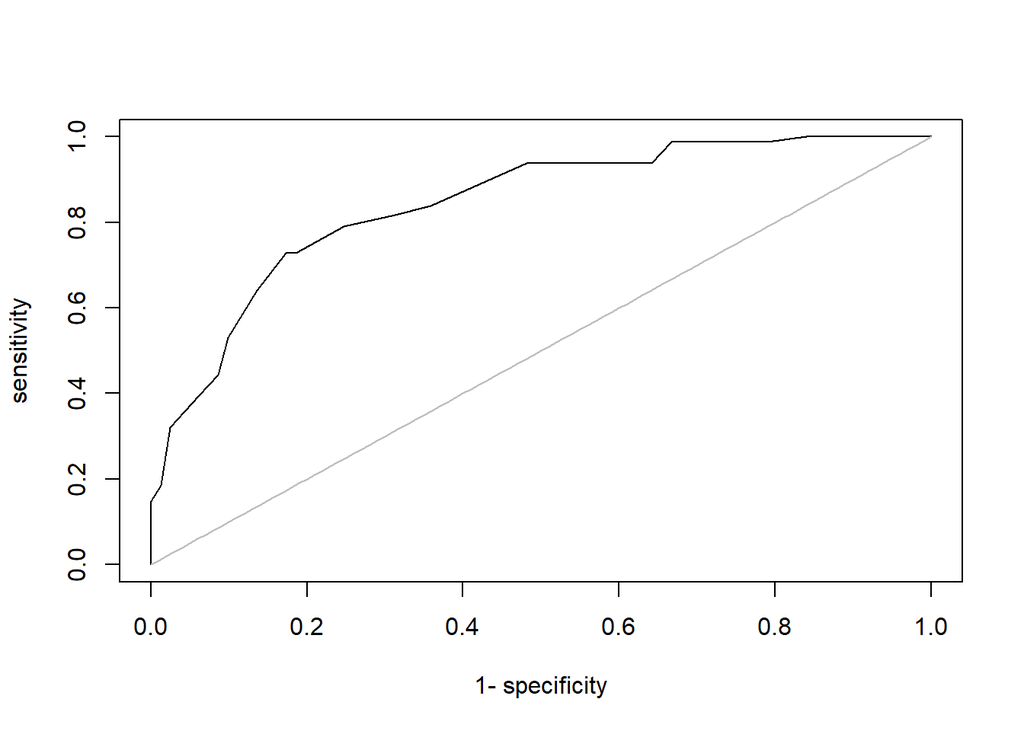

```r
plot(data.knn.prob.roc)
```

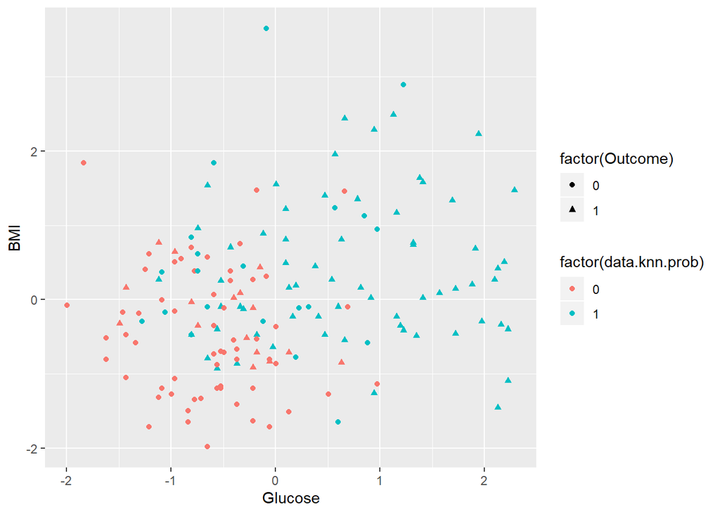

```r
ggplot(test_set_balanced)+geom_point(mapping = aes(x=Glucose, y=BMI, color=factor(data.knn.prob), shape=factor(Outcome))) # I chose glucose and BMI as the two variables because they had the highest perason correlation scores in question 2
```

red colour: predicted to not be diabetic, blue color, predicted to be diabetic by the best knn model on the balanced test data. circle shape: the actual outcome of not diabetic, triange shape: the actual outcome of being diabetic. A large number of red circles and blue triangles means a good model.